# Visium post-QC clustering and cell type annotation

Author

Harvard Chan Bioinformatics Core

Published

July 2, 2025

This code is in this revision.

```r
# library(rstudioapi)
# setwd(fs::path_dir(getSourceEditorContext()$path))
stopifnot(R.version$major >= 4) # requires R4
if (compareVersion(R.version$minor, "3.1") < 0) warning("We recommend >= R4.3.1")
stopifnot(compareVersion(as.character(BiocManager::version()), "3.18") >= 0)
stopifnot(compareVersion(as.character(packageVersion("Seurat")), "5.1") >= 0)
```

## 0.1 Project details

In this template, we assume you have already run QC on your Visium data:

- Remove genes that are contamination/poor quality-related (e.g. mitochondria or hemoglobin);
- Keep only cells that have all QC metrics passing the chosen thresholds

Now, we will move to the analysis of Visium data, we will perform:

- Normalization
- Unsupervised sketch clustering
- scRNA-seq data project

# 1 Normalize Data

Normalization is important in order to make expression counts comparable across genes and/or sample. We note that the best normalization methods for spatial data are still being developed and evaluated. Here we use a standard log-normalization.

```r
visiumHD_postQCobj <- inputRead(visium_postQCF)
assaytouse <- DefaultAssay(visiumHD_postQCobj)
message(
  "Default assay: [", assaytouse,
  "] used, please change it if another assay is of interest."
)
object_filt <- NormalizeData(visiumHD_postQCobj, assay = assaytouse)
```

# 2 Unsupervised Clustering

The authors of the `Seurat` package recommend the `Seurat` v5 **[sketch clustering](https://satijalab.org/seurat/articles/seurat5_sketch_analysis)** workflow because it exhibits improved performance, especially for identifying rare and spatially restricted groups.

Sketch-based analyses aim to “subsample” large datasets in a way that preserves rare populations. Here, we sketch the Visium HD dataset, perform clustering on the subsampled cells, and then project the cluster labels back to the full dataset.

```r
object_filt <- FindVariableFeatures(object_filt)
# we select 10,000 cells and create a new 'sketch' assay
object_filt <- SketchData(
  object = object_filt,
  assay = assaytouse,
  ncells = 10000,
  method = "LeverageScore",
  sketched.assay = "sketch"
)
```

```r
# switch analysis to sketched cells
DefaultAssay(object_filt) <- "sketch"

# perform clustering workflow
object_filt <- FindVariableFeatures(object_filt)
object_filt <- ScaleData(object_filt)
object_filt <- RunPCA(object_filt, assay = "sketch", reduction.name = "pca.sketch")
# default first 50 PCs are used
object_filt <- FindNeighbors(object_filt,
  assay = "sketch",
  reduction = "pca.sketch",
  dims = 1:50
)
# you may want to tweak resolution parameter in your own data
object_filt <- FindClusters(object_filt,
  cluster.name = "seurat_cluster.sketched",
  resolution = .65
)
```

```
Modularity Optimizer version 1.3.0 by Ludo Waltman and Nees Jan van Eck

Number of nodes: 2696
Number of edges: 90303

Running Louvain algorithm...
Maximum modularity in 10 random starts: 0.8904
Number of communities: 15
Elapsed time: 0 seconds
```

```r
# Use the same dimension of PCs for both FindNeighbors and run UMAP
object_filt <- RunUMAP(object_filt,
  reduction = "pca.sketch",
  reduction.name = "umap.sketch", return.model = T,
  dims = 1:50
)
```

```r
object_filt <- ProjectData(
  object = object_filt,
  assay = assaytouse,
  full.reduction = "full.pca.sketch",
  sketched.assay = "sketch",
  sketched.reduction = "pca.sketch",
  umap.model = "umap.sketch",
  dims = 1:50,
  refdata = list(seurat_cluster.projected = "seurat_cluster.sketched")
)
```

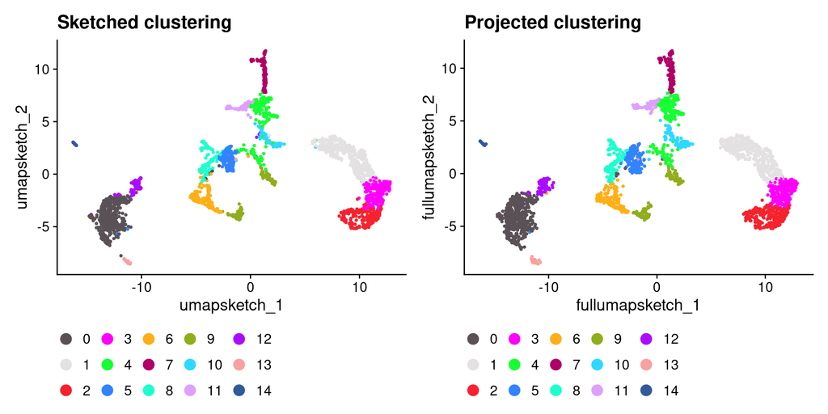

```r
object_filt$seurat_cluster.projected <- object_filt$seurat_cluster.projected %>%
  as.numeric() %>%
  as.factor()

DefaultAssay(object_filt) <- "sketch"
Idents(object_filt) <- "seurat_cluster.sketched"
p1 <- DimPlot(object_filt, reduction = "umap.sketch", label = F, cols = "polychrome") +
  ggtitle("Sketched clustering") +
  theme(legend.position = "bottom") +
  guides(color = guide_legend(override.aes = list(size = 4), ncol = 5))

# switch to full dataset
DefaultAssay(object_filt) <- assaytouse
Idents(object_filt) <- "seurat_cluster.projected"
p2 <- DimPlot(object_filt,
  reduction = "full.umap.sketch", label = F, raster = F,
  cols = "polychrome"
) +
  ggtitle("Projected clustering") +
  theme(legend.position = "bottom") +
  guides(color = guide_legend(override.aes = list(size = 4), ncol = 5))

p1 | p2
```

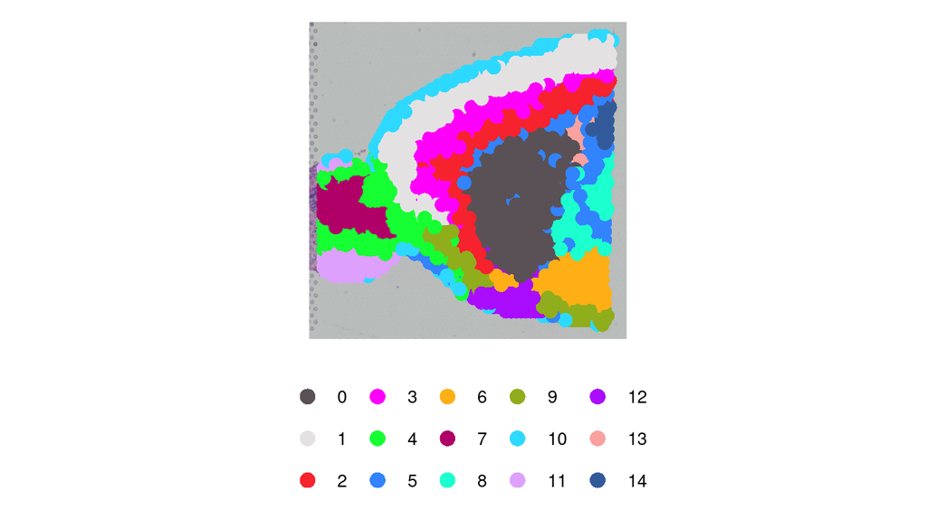

```r
color_pal <- Seurat::DiscretePalette(
  n = length(unique(object_filt$seurat_cluster.projected)),
  palette = "polychrome"
)
names(color_pal) <- sort(unique(object_filt$seurat_cluster.projected))
image_seurat_clusters <- SpatialDimPlot(object_filt,
  group.by = "seurat_cluster.projected",
  pt.size.factor = 8, cols = color_pal
) +
  theme(legend.position = "bottom", legend.title = element_blank()) +
  guides(fill = guide_legend(override.aes = list(size = 4, name = ""), ncol = 5))

image_seurat_clusters
```

# 3 Spatially-informed Clustering

BANKSY is another method for performing clustering.

Unlike Seurat, BANKSY takes into account not only an individual spot’s expression pattern but also the mean and the gradient of gene expression levels in a spot’s broader neighborhood. This makes it valuable for identifying and segmenting spatial tissue domains.

```r
# lambda: (numeric between 0-1) Spatial weight parameter
# k_geom: (integer) kNN parameter - number of neighbors to use, default is 15

# Please consider tweaking those two parameters based on your understanding of your data

object_filt <- RunBanksy(object_filt,
  lambda = 0.8, verbose = T,
  assay = assaytouse, slot = "data", k_geom = 50
)
object_filt <- RunPCA(object_filt,
  assay = "BANKSY",
  reduction.name = "pca.banksy",
  features = rownames(object_filt),
  npcs = 30
)
object_filt <- FindNeighbors(object_filt,
  reduction = "pca.banksy",
  dims = 1:30
)
# again, do not forget to try different resolutions
object_filt <- FindClusters(object_filt,
  cluster.name = "banksy_cluster",
  resolution = 0.5
)
```

```
Modularity Optimizer version 1.3.0 by Ludo Waltman and Nees Jan van Eck

Number of nodes: 2696
Number of edges: 60847

Running Louvain algorithm...
Maximum modularity in 10 random starts: 0.8841
Number of communities: 11
Elapsed time: 0 seconds
```

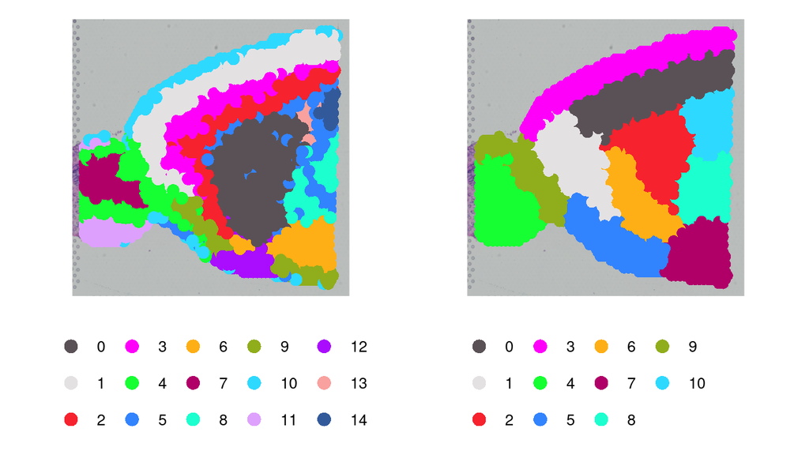

```r
color_pal <- Seurat::DiscretePalette(
  n = length(unique(object_filt$banksy_cluster)),
  palette = "polychrome"
)
names(color_pal) <- sort(unique(object_filt$banksy_cluster))

image_banksy_clusters <- SpatialDimPlot(object_filt,
  group.by = "banksy_cluster",
  pt.size.factor = 7,
  cols = color_pal
) +
  theme(legend.position = "bottom", legend.title = element_blank()) +
  guides(fill = guide_legend(override.aes = list(size = 4, name = ""), ncol = 5))

image_seurat_clusters | image_banksy_clusters
```

# 4 Cell Type Annotation

Perhaps we are particularly interested in understanding the organization of cell types in the cortical region of the brain.

We first subset our Seurat object to this region of interest.

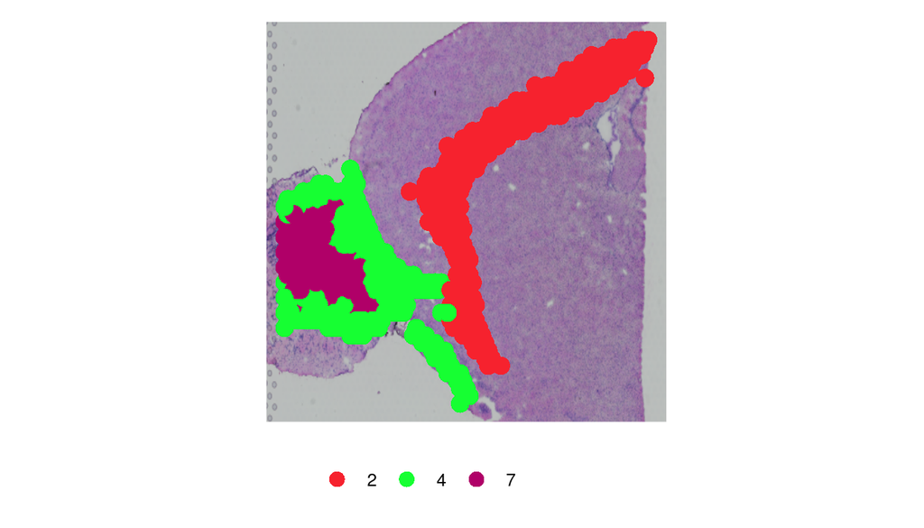

```r
# change the list of clusters to your interest regions based on previous clustering results
ROI <- subset(object_filt, seurat_cluster.projected %in% c(18, 19, 7, 2, 4))

color_pal <- Seurat::DiscretePalette(
  n = length(unique(object_filt$seurat_cluster.projected)),
  palette = "polychrome"
)
names(color_pal) <- sort(unique(object_filt$seurat_cluster.projected))
SpatialDimPlot(ROI,
  group.by = "seurat_cluster.projected",
  pt.size.factor = 8, cols = color_pal
) +
  theme(legend.position = "bottom", legend.title = element_blank()) +
  guides(fill = guide_legend(override.aes = list(size = 4, name = ""), ncol = 5))
```

To perform accurate annotation of cell types, we must also take into consideration that our 16 um spots may contain one or more cells each. The method Robust Cell Type Deconvolution (**RCTD**) has been shown to accurately annotate spatial data from a variety of technologies while taking into consideration that a single spot may exhibit multiple cell type profiles.

RCTD takes an scRNA-seq dataset as a reference and a spatial dataset as a query. For a reference, we use a subsampled version of the mouse scRNA-seq dataset from the Allen Brain Atlas. We use our cortex Seurat object as the spatial query. For computational efficiency, we sketch the spatial query dataset, apply RCTD to deconvolute the ‘sketched’ cortical cells and annotate them, and then project these annotations to the full cortical dataset.

```r
DefaultAssay(ROI) <- assaytouse
ROI <- FindVariableFeatures(ROI)
ROI <- SketchData(
  object = ROI,
  ncells = 3000,
  method = "LeverageScore",
  sketched.assay = "sketch"
)

DefaultAssay(ROI) <- "sketch"
ROI <- ScaleData(ROI)
ROI <- RunPCA(ROI, assay = "sketch", reduction.name = "pca.ROI.sketch", verbose = T)
ROI <- FindNeighbors(ROI, reduction = "pca.ROI.sketch", dims = 1:50)
ROI <- RunUMAP(ROI, reduction = "pca.ROI.sketch", reduction.name = "umap.ROI.sketch", return.model = T, dims = 1:50, verbose = T)

counts_hd <- ROI[["sketch"]]$counts
ROI_cells_hd <- colnames(ROI[["sketch"]])
coords <- GetTissueCoordinates(ROI)[ROI_cells_hd, 1:2]

# create the RCTD query object
query <- SpatialRNA(coords, counts_hd, colSums(counts_hd))
```

# 5 Reference projection

```r
ref_subset <- inputRead(scrna_refF)
# Check the label column you want to use from the scRNA-seq obs data
Idents(ref_subset) <- "subclass_label"
counts <- ref_subset[["RNA"]]$counts
cluster <- as.factor(ref_subset$subclass_label)
nUMI <- ref_subset$nCount_RNA
levels(cluster) <- gsub("/", "-", levels(cluster))
cluster <- droplevels(cluster)

# create the RCTD reference object
reference <- Reference(counts, cluster, nUMI)
```

```r
RCTD <- create.RCTD(query, reference, max_cores = 6)
```

```
          Astro        CA1-ProS       CA2-IG-FC             CA3            Car3
            500             500             101             442             500
             CR          CT SUB              DG            Endo      L2 IT ENTl
            208             500             500             500             500
     L2 IT ENTm     L2-3 IT CTX    L2-3 IT ENTl     L2-3 IT PPP     L2-3 IT RHP
            433             500             500             500             500
      L3 IT ENT      L4 RSP-ACA     L4-5 IT CTX       L5 IT CTX          L5 PPP
            500             500             500             500             254
      L5 PT CTX L5-6 IT TPE-ENT     L5-6 NP CTX       L6 CT CTX       L6 IT CTX
            500             500             500             500             500
     L6 IT ENTl         L6b CTX      L6b-CT ENT           Lamp5       Micro-PVM
            273             500             500             500             500
         NP PPP          NP SUB           Oligo           Pvalb        SMC-Peri
            500             398             500             500             285
           Sncg             Sst       Sst Chodl        SUB-ProS             Vip
            500             500             495             500             500
           VLMC
            152
```

```r
RCTD <- run.RCTD(RCTD, doublet_mode = "doublet") # this command takes ~15 mins to run

# add results back to Seurat object
ROI <- AddMetaData(ROI, metadata = RCTD@results$results_df)
```

```r
ROI$first_type <- as.character(ROI$first_type)
ROI$first_type[is.na(ROI$first_type)] <- "Unknown"
ROI <- ProjectData(
  object = ROI,
  assay = assaytouse,
  full.reduction = "pca.ROI",
  sketched.assay = "sketch",
  sketched.reduction = "pca.ROI.sketch",
  umap.model = "umap.ROI.sketch",
  dims = 1:50,
  refdata = list(full_first_type = "first_type")
)
```

We can see that the excitatory neurons (`L.* CTX`) are located in layers at varying cortical depths, as expected

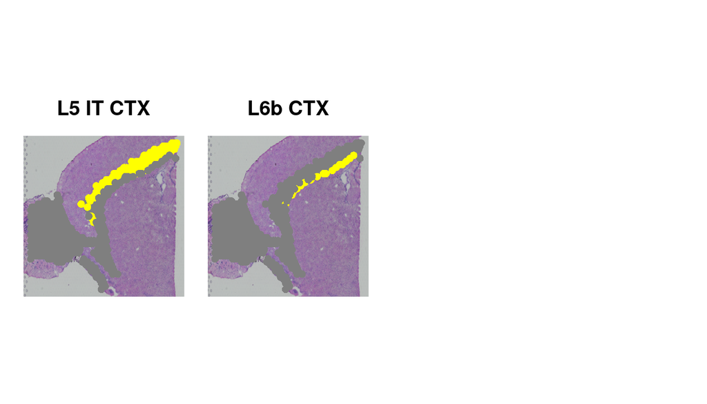

```r
Idents(ROI) <- "full_first_type"
cells <- CellsByIdentities(ROI)
# Layered (starts with L), excitatory neurons in the ROI
excitatory_names <- sort(grep("^L.* CTX", names(cells), value = TRUE))
SpatialDimPlot(ROI,
  cells.highlight = cells[excitatory_names],
  cols.highlight = c("#FFFF00", "grey50"), facet.highlight = T,
  combine = T, ncol = 4, pt.size.factor = 8
)
```

## 5.1 Methods

### 5.1.1 Citation

```r
citation("Seurat")
```

```
  Hao et al. Dictionary learning for integrative, multimodal and
  scalable single-cell analysis. Nature Biotechnology (2023) [Seurat
  V5]

  Hao and Hao et al. Integrated analysis of multimodal single-cell
  data. Cell (2021) [Seurat V4]

  Stuart and Butler et al. Comprehensive Integration of Single-Cell
  Data. Cell (2019) [Seurat V3]

  Butler et al. Integrating single-cell transcriptomic data across
  different conditions, technologies, and species. Nat Biotechnol
  (2018) [Seurat V2]

  Satija and Farrell et al. Spatial reconstruction of single-cell gene
  expression data. Nat Biotechnol (2015) [Seurat V1]

To see these entries in BibTeX format, use 'print(<citation>,
bibtex=TRUE)', 'toBibtex(.)', or set
'options(citation.bibtex.max=999)'.
```

```r
citation("Banksy")
```

```
  Singhal, V., Chou, N., et al. BANKSY: A Spatial Omics Algorithm that
  Unifies Cell Typing and Tissue Domain Segmentation Preprint at
  bioRxiv https://doi.org/10.1101/2022.04.14.488259 (2022)

A BibTeX entry for LaTeX users is

  @Article{,
    title = {BANKSY: A Spatial Omics Algorithm that Unifies Cell Typing and Tissue Domain Segmentation},
    author = {Vipul Singhal and Nigel Chou and Joseph Lee and Jinyue Liu and Wan Kee Chock and Li Lin and Yun-Ching Chang and Erica Teo and Hwee Kuan Lee and Kok Hao Chen and Shyam Prabhakar},
    journal = {bioRxiv},
    year = {2022},
    url = {https://www.biorxiv.org/content/10.1101/2022.04.14.488259},
  }
```

```r
citation("quadprog")
```

[output not shown]

```r
citation("spacexr")
```

```
  Cable D (????). _spacexr: SpatialeXpressionR: Cell type
  identification and cell type-specific differential expression in
  spatial transcriptomics_. R package version 2.2.1, commit
  744153c633da7ff70d0988308a160633fcf44af7,
  <https://github.com/dmcable/spacexr>.

A BibTeX entry for LaTeX users is

  @Manual{,
    title = {spacexr: SpatialeXpressionR: Cell type identification and cell type-specific differential expression in spatial transcriptomics},
    author = {Dylan Cable},
    note = {R package version 2.2.1, commit 744153c633da7ff70d0988308a160633fcf44af7},
    url = {https://github.com/dmcable/spacexr},
  }

ATTENTION: This citation information has been auto-generated from the
package DESCRIPTION file and may need manual editing, see
'help("citation")'.
```